# Filters and joins

Allison Horst

1/28/2020

Get some fish.csv and kelp_fronds.xlsx

```r
fish <- read_csv(here("data","fish.csv"))
kelp_abur <- read_excel(here("data","kelp_fronds.xlsx"),
                        sheet = "abur")
```

### Filter by an exact match

Exact match: `==`

Example 1: only keep observations from `fish` where the common_name variable matches (==) “garibaldi”

```r
fish_garibaldi <- fish %>%
  filter(common_name == "garibaldi")
```

> , <, >=, <=, ==

Create a subset of fish called fish_over50, starting from fish, where the total_count is greater than OR equal to 50

```r
fish_over50 <- fish %>%
  filter(total_count >= 50)
```

### What if we want to filter by this OR this?

Use can use the vertical line `|` “or”

```r
fish_2sp <- fish %>%
  filter(common_name == "garibaldi" | common_name == "blacksmith")

# If you're filtering for multiple matches within the same variable, you can use %in%

fish_3sp <- fish %>%
  filter(common_name %in% c("garibaldi","blacksmith","black surfperch"))

# View(fish_2sp)
```

Activity: subset from fish (fish_gar_2016) that keeps all observations where the year is 2016 OR the common_name is “garibaldi”

```r
fish_gar_2016 <- fish %>%
  filter(year == 2016 | common_name == "garibaldi")
```

### Filter to match this AND that

, or &

```r
aque_2018 <- fish %>%
  filter(year == 2018, site == "aque")
```

To exclude things: `!=`

### stringr::str_detect()

```r
fish_black <- fish %>%
  filter(str_detect(common_name, pattern = "black"))
```

Subset of data if the common name must include the string “it”?

```r
fish_it <- fish %>%
  filter(str_detect(common_name, pattern = "it"))
```

### `dplyr::*_join`

```r
ab_kelpfish <- kelp_abur %>%
  full_join(fish, by = c("year","site"))
```

### left_join() to keep all from x, and merge matching things from y with it (exclude things from y that don’t have a match in x)

```r
kelp_fish_left <- kelp_abur %>%
  left_join(fish, by = c("year","site"))
```

### inner_join() to merge data frames, only keepings observations with a match in both

`inner_join()`

```r
kelp_fish_injoin <- kelp_abur %>%
  inner_join(fish, by = c("year","site"))
```

### Pipe together multiple steps

- create an object called `my_fish_join`
- starting from `fish`
- filtering to only including observations at site “abur” from the year 2017
- join the kelp_abur data frame to the resulting subset using left_join()
- add a new column (`mutate()`) to calculate fish per kelp frond density (counts of fish / total fronds)

```r
my_fish_join <- fish %>%
  filter(year == 2017, site == "abur") %>%
  left_join(kelp_abur, by = c("year","site")) %>%
  mutate(fish_per_frond = total_count/total_fronds)
```

Nice HTML table using kable + kableExtra

```r
my_fish_join %>%
  kable() %>%
  kable_styling(bootstrap_options = "striped",
                full_width = FALSE)
```

| year | site | common_name | total_count | month | total_fronds | fish_per_frond |
| --- | --- | --- | --- | --- | --- | --- |
| 2017 | abur | black surfperch | 4 | 7 | 17 | 0.2352941 |
| 2017 | abur | blacksmith | 1 | 7 | 17 | 0.0588235 |
| 2017 | abur | garibaldi | 1 | 7 | 17 | 0.0588235 |
| 2017 | abur | rock wrasse | 57 | 7 | 17 | 3.3529412 |
| 2017 | abur | senorita | 64 | 7 | 17 | 3.7647059 |

ggplot(data = ?, aes(x = ?, y = ?)) + geom_?

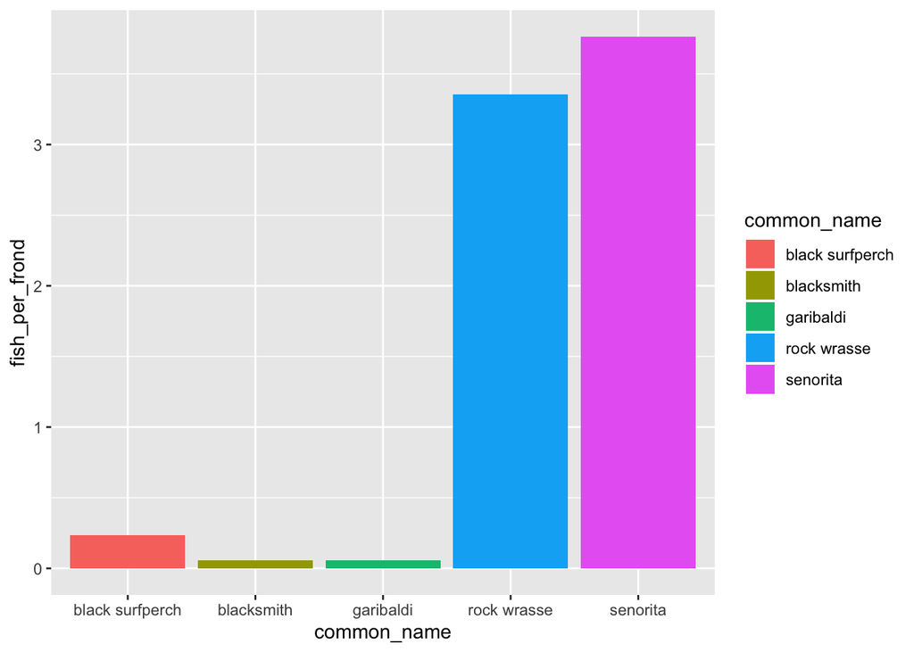

```r
ggplot(data = my_fish_join, aes(x = common_name, y = fish_per_frond)) +
  geom_col(aes(fill = common_name))
```